# Quicksort performance analysis

Ilya Meignan–Masson and Nour El hassane

2022-11-10

# Problem statement

Improve the experimental design and the performance evaluation of a simple parallel quicksort implementation. This would be done by taking into account the replication and randomization concepts, so that we have reliable unbiaised evaluations.

# Experimental design

## Generate the arrays of parameters (number of execution repetitions and different array sizes)

```r
number_of_repetitions <- c(0:10)
sizes <- c("100","500", "1000","5000", "10000","50000", "100000")
```

## Generate the combinations

```r
experiments <- crossing(number_of_repetitions, sizes) #pseudo-replication
experiments <- experiments[sample(1:nrow(experiments)), ]#randomization
experiments
```

```
## # A tibble: 77 × 2
##    number_of_repetitions sizes
##                    <int> <chr>
##  1                     5 5000
##  2                     9 1000
##  3                     4 500
##  4                     3 100
##  5                     8 500
##  6                     5 500
##  7                     6 10000
##  8                     3 5000
##  9                    10 100
## 10                     7 5000
## # … with 67 more rows
```

## Run the functions

```r
# store the experiments parameters in a csv file
write.csv(experiments, "../data/nour_2023-01-03/experiments.csv", row.names=FALSE)
```

Then, from the project directory /M2R-ParallelQuicksort, execute the run_benchmarking.sh script (located in scripts folder).

```bash
cd /home/nour/projects/ENSIMAG/SMPE/M2R-ParallelQuicksort
./scripts/run_benchmarking.sh
```

Once experiments are run, we convert the measurements.txt file to a measurements.csv file to perfom data analysis on it.

```bash
cd /home/nour/projects/ENSIMAG/SMPE/M2R-ParallelQuicksort
./scripts/csv_quicksort_extractor.sh
```

# Analysis of the results

```r
df <- read.csv(file="../data/nour_2023-01-03/measurements.csv", sep=",",header = FALSE)
names(df) <- c('Size','Function','Execution_time')
summary(df)
```

```
##       Size           Function Execution_time
##  Min.   :   100   Min.   :0   Min.   :0.0000080
##  1st Qu.:   500   1st Qu.:0   1st Qu.:0.0001163
##  Median :  5000   Median :1   Median :0.0028575
##  Mean   : 23800   Mean   :1   Mean   :0.0086232
##  3rd Qu.: 50000   3rd Qu.:2   3rd Qu.:0.0171640
##  Max.   :100000   Max.   :2   Max.   :0.1504700
```

Calculate the mean execution time (sample mean) for each function. Function 0 is the sequential sort, 1 is the parallel quicksort, and 2 is the Built-in sort.

```r
sample_means <- df %>% group_by(Function) %>% summarise(Sn=mean(`Execution_time`))
sample_means
```

```
## # A tibble: 3 × 2
##   Function      Sn
##      <int>   <dbl>
## 1        0 0.00427
## 2        1 0.0176
## 3        2 0.00398
```

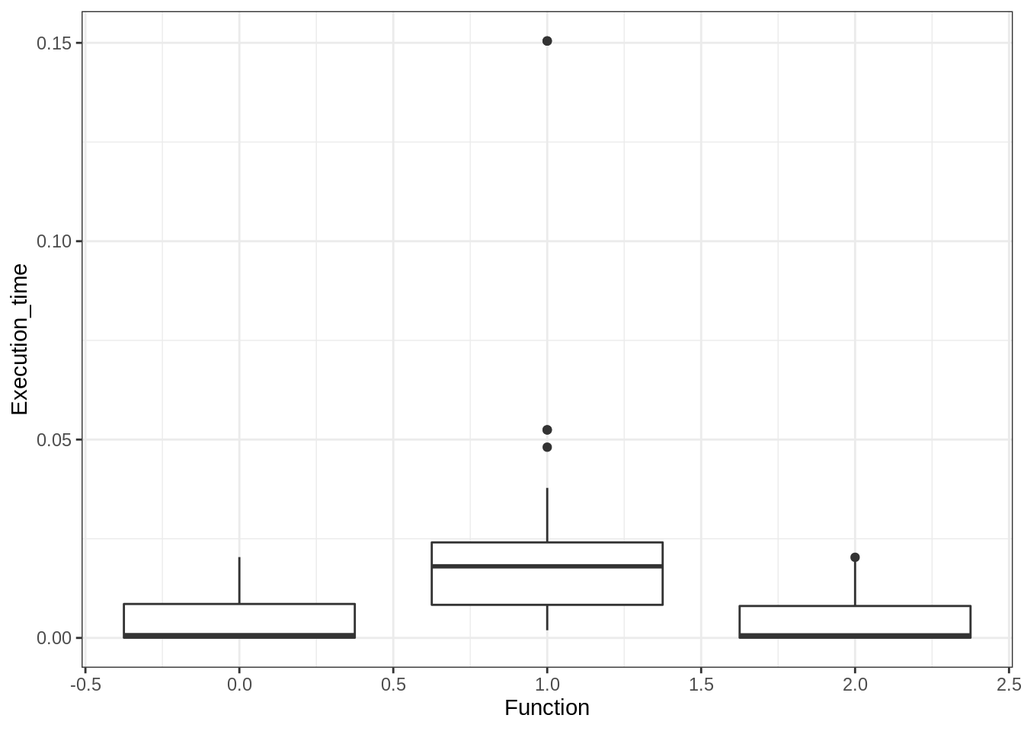

```r
ggplot(data=df,aes(x=Function,y=Execution_time, group=factor(Function)))+ geom_boxplot() + theme_bw()
```

```r
min_1 <-min(df$Execution_time[df$Function==1])
max_0 <- max(df$Execution_time[df$Function==0])
max_2 <- max(df$Execution_time[df$Function==2])
print(paste(min_1,max_0,max_2))
```

```
## [1] "0.001938 0.020375 0.020324"
```

Min execution time of the parallel quicksort is less than max sequential and max built-in. Thus, intervals overlap! Compare Var(1-0) to Var(1) and Var(0), and repeat the same for Var(1-2) comapred to Var(1) and Var(2).

```r
df_0<-df$Execution_time[df$Function==0]
df_1<-df$Execution_time[df$Function==1]
df_2<-df$Execution_time[df$Function==2]
cat("Var(1-0): ",var(df_1-df_0))
```

```
## Var(1-0):  0.0001228874
```

```r
cat("\nVar(1): ",var(df_1))
```

```
##
## Var(1):  0.0001726955
```

```r
cat("\nVar(0): ",var(df_0))
```

```
##
## Var(0):  4.266532e-05
```

```r
cat("Var(1-2): ",var(df_1-df_2))
```

```
## Var(1-2):  0.0001231591
```

```r
cat("\nVar(1): ",var(df_1))
```

```
##
## Var(1):  0.0001726955
```

```r
cat("\nVar(2): ",var(df_2))
```

```
##
## Var(2):  3.754721e-05
```

Therefore, we can say that through this experimental analysis, it appeared that the Built-in quicksort function is better than the parallel quicksort function.

Note that in a previous experiment, Var(1-2) was smaller than Var(1) but bigger than Var(2), so we considered the Variable 1-2 and did a boxplot. We found that E[1-2]>0 => E[1] > E[2], which means that C quicksort is better than the parallel quicksort.